# Growth Mortality Initial Tree Ring Analysis

Carmen

December 11, 2018

# Sources:

- https://rpubs.com/andybunn/r4tree-rings
- Speer, J. H. (2010). Fundamentals of tree-ring research. Tucson: University of Arizona Press.
- to ask an expert questions, go to itrdbfor.org

# General notes:

- **Standardization** = **Detrending** = removing age-related growth trends and other long-term variability that can be considered noise
  - often, a climatologist’s signal is an ecologist’s noise
  - produces a series mean of 1
  - Technique #1: **negative exponential curve**
    - determined by the geometry of how much narrower a ring gets when you add the same volume of wood to a larger cylinder
    - deterministic = same eqn for every data set
  - Technique #2: **cubic smoothing spline**
    - a 40 year one removes 50% of variance, removes 99% of variance at 126 years, and removes only 1% of variance at 12.67 years
    - more flexible than negative exponential curve
  - Technique #3: **regional curve standardization**
    - advantage: splines often remove long-term trends that are not age-related, like the Little Ice Age
    - based on the biological age of each ring
      - therefore you have to age each core
    - regional curve = average growth for that stand, which is removed from each core
    - must have at least 5 trees for any section of the curve and at least 40 trees at densest part of the curve
  - Technique #4: **signal-free method**
    - don’t know anything about this other than that Andy Bunn says there’s been a lot of interest in including it in `dplR` but it’s not there yet
  - once a `rwl` data set is detrended, it becomes a `rwi` (ring-width index) file
    - at which point every series has a mean of 1

# Example with built-in data

```r
data(ca533)
```

## This is a special kind of data frame specific to dendro analysis

```r
class(ca533)
```

```
## [1] "rwl"        "data.frame"
```

In order to create a rwl data frame, you use the function `read.rwl`

## Time (years) is an attribute of this class

```r
head(time(ca533))
```

```
## [1] 626 627 628 629 630 631
```

# Rwl data frames can easily be plotted in a dendro way

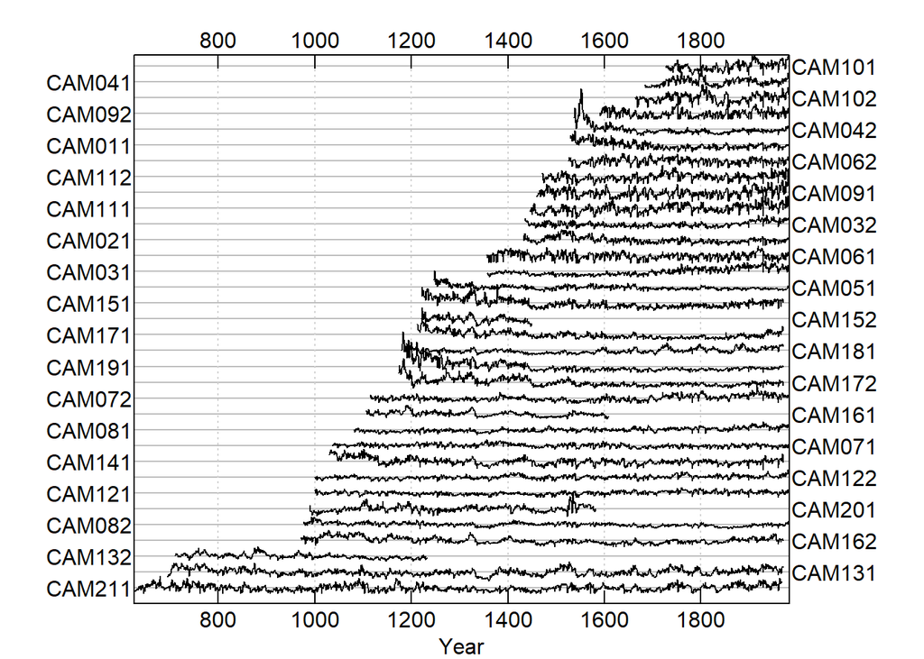

```r
plot(ca533, plot.type = "spag")
```

# And described with descriptive stats

```r
rwl.report(ca533)
```

```
## Number of dated series: 34
## Number of measurements: 23276
## Avg series length: 684.5882
## Range:  1358
## Span:  626 - 1983
## Mean (Std dev) series intercorrelation: 0.6294255 (0.0859289)
## Mean (Std dev) AR1: 0.7092647 (0.09811876)
## -------------
## Years with absent rings listed by series
##     Series CAM011 -- 1753 1782
##     Series CAM031 -- 1497 1500 1523 1533 1540 1542 1545 1578 1579 1580 1655 1668 1670 1681
##     Series CAM032 -- 1497 1523 1579 1654 1670 1681 1782
##     Series CAM051 -- 1475
##     Series CAM061 -- 1497 1523 1542 1545 1547 1579 1654 1655 1668 1670 1672 1782 1858 1960
##     Series CAM062 -- 1542 1545 1547 1548 1579 1654 1655 1670 1672 1782 1836 1857 1858 1929
##     Series CAM071 -- 1269 1497 1498 1523 1542 1547 1578 1579 1612 1655 1656 1668 1670 1672 1674 1690 1707 1708 1756 1782 1795 1820 1836 1845 1857 1858 1924 1948 1960
##     Series CAM072 -- 1218 1497 1498 1523 1533 1538 1542 1545 1546 1547 1571 1579 1580 1590 1654 1655 1668 1670 1672 1675 1690
##     Series CAM081 -- 1218 1336
##     Series CAM082 -- 1362 1858 1865
##     Series CAM091 -- 1655 1669 1670 1782 1858
##     Series CAM092 -- 1624 1654 1655 1670 1672 1675 1677 1690 1703 1705 1707 1708 1710 1733 1753 1756 1757 1774 1777 1781 1782 1783 1784 1795 1807 1824 1829 1836 1845 1857 1858 1899 1904 1929 1936 1961
##     Series CAM101 -- 1782 1783 1899 1929
##     Series CAM102 -- 1669 1690 1782 1858 1899 1929
##     Series CAM111 -- 1542
##     Series CAM112 -- 1542
##     Series CAM121 -- 1093 1218 1254 1361 1365 1460 1462 1468 1473 1475 1492 1497 1542 1544 1545 1547 1600 1899 1960
##     Series CAM122 -- 1117 1133 1147 1177 1218 1254 1361 1475 1497 1670
##     Series CAM131 -- 1361
##     Series CAM151 -- 1670 1703
##     Series CAM161 -- 1523
##     Series CAM162 -- 1618 1624 1641
##     Series CAM181 -- 1450 1523
##     Series CAM191 -- 1475 1497 1523 1533 1542 1558 1571 1578 1618 1655 1668 1670 1675 1677 1690 1705 1777 1929
##     Series CAM201 -- 1523
##     Series CAM211 -- 645 762 809 847 924 957 1014 1118 1123 1133 1147 1189 1350 1384 1468 1571 1641
## 234 absent rings (1.005%)
## -------------
## Years with internal NA values listed by series
##     None
```

```r
summary(ca533)
```

```
##    series first last year  mean median stdev   skew  gini   ar1
## 1  CAM011  1530 1983  454 0.440   0.40 0.222  1.029 0.273 0.696
## 2  CAM021  1433 1983  551 0.424   0.40 0.185  0.946 0.237 0.701
## 3  CAM031  1356 1983  628 0.349   0.29 0.214  0.690 0.341 0.808
## 4  CAM032  1435 1983  549 0.293   0.26 0.163  0.717 0.309 0.661
## 5  CAM041  1683 1983  301 0.526   0.53 0.223  0.488 0.238 0.690
## 6  CAM042  1538 1983  446 0.439   0.36 0.348  3.678 0.324 0.880
## 7  CAM051  1247 1983  737 0.273   0.25 0.140  1.836 0.262 0.705
## 8  CAM061  1357 1983  627 0.462   0.47 0.202 -0.111 0.247 0.509
## 9  CAM062  1525 1983  459 0.442   0.45 0.188 -0.266 0.240 0.529
## 10 CAM071  1037 1983  947 0.249   0.25 0.109  0.027 0.247 0.577
## 11 CAM072  1114 1983  870 0.309   0.29 0.163  0.698 0.292 0.735
## 12 CAM081  1081 1983  903 0.327   0.31 0.124  0.555 0.211 0.716
## 13 CAM082   977 1983 1007 0.285   0.29 0.114  0.312 0.223 0.767
## 14 CAM091  1460 1983  524 0.532   0.52 0.255  0.425 0.267 0.628
```

[output cut: 20 more lines]

**Note: Bunn thinks that mean sensitivity is a terrible statistic that should not be used

## which you can then plot

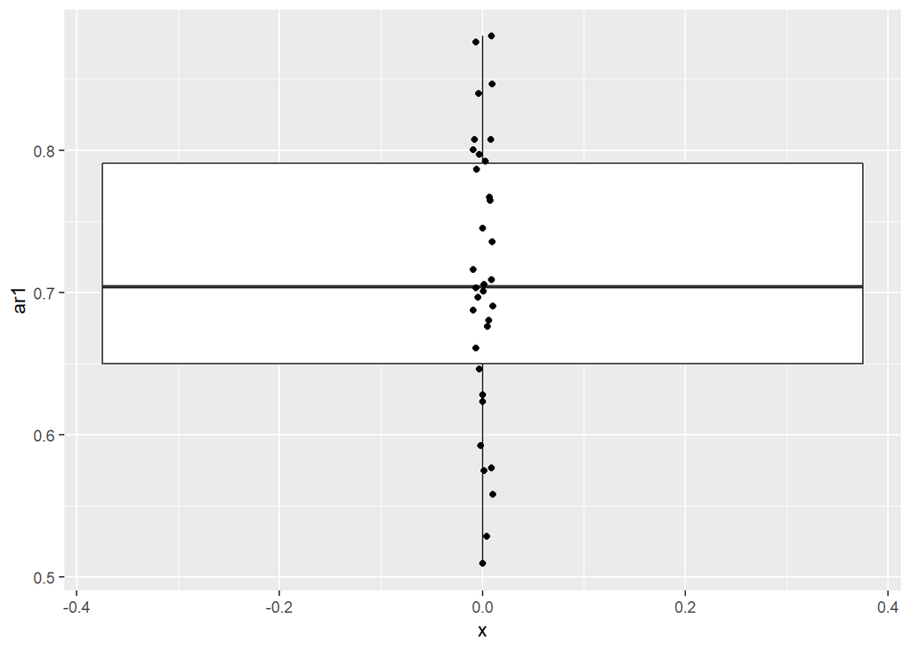

```r
ggplot(summary(ca533))+
  geom_boxplot(aes(y = ar1))+
  geom_jitter(aes(y = ar1, x = 0), width = .01)
```